# Laboratorium 4: Miary dopasowania modeli wieloklasowych - rozwiązania

Author

Dariusz Majerek

```r
library(tidymodels)
library(tidyverse)
library(modeldata)
```

## Zadanie 1

### 1. Rozkład klas i weryfikacja losowania warstwowego

```r
set.seed(2026)

penguins_clean <- penguins %>% drop_na()

# proporcje w pełnym zbiorze
penguins_clean %>%
  count(species) %>%
  mutate(prop = round(n / sum(n) * 100, 1))
```

```
# A tibble: 3 × 3
  species       n  prop
  <fct>     <int> <dbl>
1 Adelie      146  43.8
2 Chinstrap    68  20.4
3 Gentoo      119  35.7
```

```r
# podział warstwowy
split_peng <- initial_split(penguins_clean, prop = 0.7, strata = species)
train_peng <- training(split_peng)
test_peng <- testing(split_peng)

# proporcje w zbiorze treningowym
train_peng %>%
  count(species) %>%
  mutate(prop = round(n / sum(n) * 100, 1))
```

```
# A tibble: 3 × 3
  species       n  prop
  <fct>     <int> <dbl>
1 Adelie      102  44
2 Chinstrap    47  20.3
3 Gentoo       83  35.8
```

```r
# proporcje w zbiorze testowym
test_peng %>%
  count(species) %>%
  mutate(prop = round(n / sum(n) * 100, 1))
```

```
# A tibble: 3 × 3
  species       n  prop
  <fct>     <int> <dbl>
1 Adelie       44  43.6
2 Chinstrap    21  20.8
3 Gentoo       36  35.6
```

Losowanie warstwowe zachowuje proporcje klas – w obu zbiorach rozkład `species` jest zbliżony do oryginału.

### 2. Model wieloklasowej regresji logistycznej

```r
multinom_spec <- multinom_reg() %>%
  set_engine("nnet") %>%
  set_mode("classification")

multinom_fit <- multinom_spec %>%
  fit(species ~ ., data = train_peng)
```

### 3. Predykcje klas i prawdopodobieństw

```r
pred_peng <- test_peng %>%
  select(species) %>%
  bind_cols(predict(multinom_fit, new_data = test_peng)) %>%
  bind_cols(predict(multinom_fit, new_data = test_peng, type = "prob"))

head(pred_peng)
```

```
# A tibble: 6 × 5
  species .pred_class .pred_Adelie .pred_Chinstrap .pred_Gentoo
  <fct>   <fct>              <dbl>           <dbl>        <dbl>
1 Adelie  Adelie                 1       5.11e- 48     1.54e-29
2 Adelie  Adelie                 1       3.58e- 52     1.37e-35
3 Adelie  Adelie                 1       1.98e- 95     1.07e-45
4 Adelie  Adelie                 1       6.24e-140     5.20e-82
5 Adelie  Adelie                 1       3.88e- 71     1.90e-45
6 Adelie  Adelie                 1       7.26e- 80     3.48e-45
```

### 4. Macierz klasyfikacji

```r
cm_peng <- pred_peng %>%
  conf_mat(truth = species, estimate = .pred_class)
cm_peng
```

```
           Truth
Prediction  Adelie Chinstrap Gentoo
  Adelie        44         0      0
  Chinstrap      0        21      0
  Gentoo         0         0     36
```

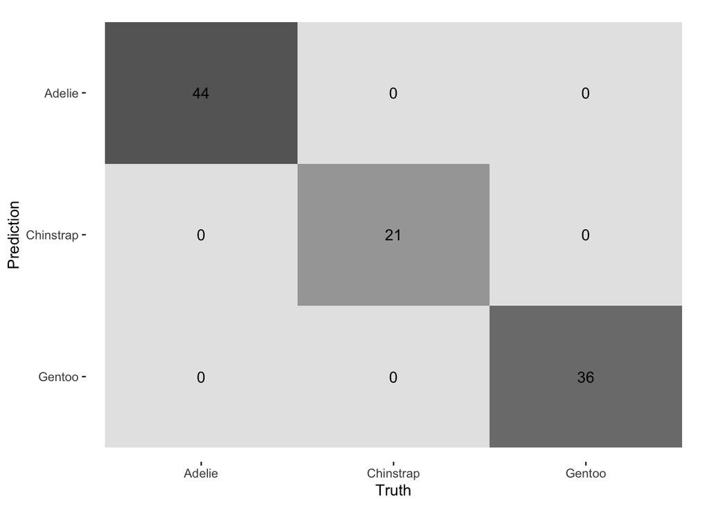

```r
cm_peng %>% autoplot(type = "heatmap")
```

### 5. Metryki z trzema estymatorami

```r
my_metrics <- metric_set(accuracy, precision, recall, f_meas, kap)

# macro
my_metrics(pred_peng,
           truth = species,
           estimate = .pred_class,
           estimator = "macro")
```

```
# A tibble: 5 × 3
  .metric   .estimator .estimate
  <chr>     <chr>          <dbl>
1 accuracy  multiclass         1
2 precision macro              1
3 recall    macro              1
4 f_meas    macro              1
5 kap       multiclass         1
```

```r
# macro_weighted
my_metrics(pred_peng,
           truth = species,
           estimate = .pred_class,
           estimator = "macro_weighted")
```

```
# A tibble: 5 × 3
  .metric   .estimator     .estimate
  <chr>     <chr>              <dbl>
1 accuracy  multiclass             1
2 precision macro_weighted         1
3 recall    macro_weighted         1
4 f_meas    macro_weighted         1
5 kap       multiclass             1
```

```r
# micro
my_metrics(pred_peng,
           truth = species,
           estimate = .pred_class,
           estimator = "micro")
```

```
# A tibble: 5 × 3
  .metric   .estimator .estimate
  <chr>     <chr>          <dbl>
1 accuracy  multiclass         1
2 precision micro              1
3 recall    micro              1
4 f_meas    micro              1
5 kap       multiclass         1
```

### 6. Odpowiedź

Estymator **makro** jest najbardziej wrażliwy na klasę mniejszościową, ponieważ przyznaje każdej klasie równą wagę (1/k). Jeśli model źle klasyfikuje małą klasę, jej niska metryka obniża średnią tak samo jak metryka klasy dominującej. Estymatory makro-ważony i mikro faworyzują klasy z większą liczbą obserwacji, więc słabsze wyniki na klasie mniejszościowej mają mniejszy wpływ na końcowy wynik.

## Zadanie 2

### 1. Rozkład klas

```r
set.seed(2026)

hpc <- hpc_data %>%
  select(class, compounds, iterations, num_pending, hour, day) %>%
  mutate(day = factor(day))

hpc %>%
  count(class) %>%
  mutate(prop = round(n / sum(n) * 100, 1))
```

```
# A tibble: 4 × 3
  class     n  prop
  <fct> <int> <dbl>
1 VF     2211  51.1
2 F      1347  31.1
3 M       514  11.9
4 L       259   6
```

```r
split_hpc <- initial_split(hpc, prop = 0.7, strata = class)
train_hpc <- training(split_hpc)
test_hpc <- testing(split_hpc)

# proporcje w zbiorach
train_hpc %>%
  count(class) %>%
  mutate(prop = round(n / sum(n) * 100, 1))
```

```
# A tibble: 4 × 3
  class     n  prop
  <fct> <int> <dbl>
1 VF     1551  51.2
2 F       937  30.9
3 M       356  11.7
4 L       186   6.1
```

```r
test_hpc %>%
  count(class) %>%
  mutate(prop = round(n / sum(n) * 100, 1))
```

```
# A tibble: 4 × 3
  class     n  prop
  <fct> <int> <dbl>
1 VF      660  50.7
2 F       410  31.5
3 M       158  12.1
4 L        73   5.6
```

Klasa *L* stanowi bardzo mały odsetek danych. Losowanie warstwowe zapewnia proporcjonalną reprezentację we wszystkich zbiorach.

### 2. Budowa dwóch modeli

```r
# wieloklasowa regresja logistyczna
multinom_spec2 <- multinom_reg() %>%
  set_engine("nnet") %>%
  set_mode("classification")

multinom_fit2 <- multinom_spec2 %>%
  fit(class ~ ., data = train_hpc)

pred_multinom <- test_hpc %>%
  select(class) %>%
  bind_cols(predict(multinom_fit2, new_data = test_hpc)) %>%
  bind_cols(predict(multinom_fit2, new_data = test_hpc, type = "prob")) %>%
  mutate(model = "multinom")

# kNN
knn_spec <- nearest_neighbor(neighbors = 11) %>%
  set_engine("kknn") %>%
  set_mode("classification")

knn_rec <- recipe(class ~ ., data = train_hpc) %>%
  step_normalize(all_numeric_predictors())

knn_wf <- workflow() %>%
  add_recipe(knn_rec) %>%
  add_model(knn_spec)

knn_fit <- knn_wf %>% fit(data = train_hpc)

pred_knn <- test_hpc %>%
  select(class) %>%
  bind_cols(predict(knn_fit, new_data = test_hpc)) %>%
  bind_cols(predict(knn_fit, new_data = test_hpc, type = "prob")) %>%
  mutate(model = "knn")
```

### 3. Wieloklasowa krzywa ROC i AUC

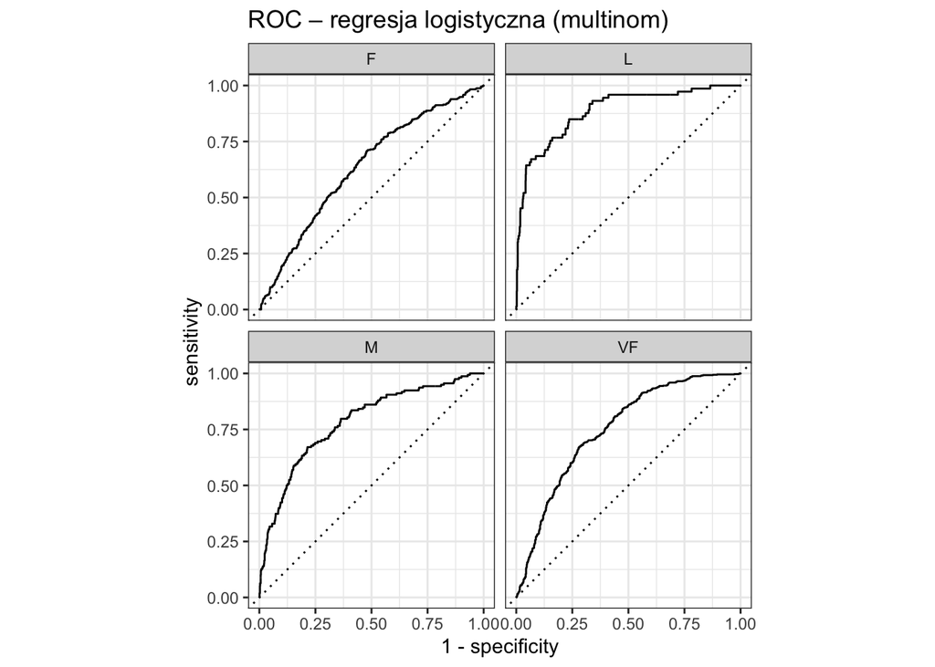

```r
# ROC – multinom
pred_multinom %>%
  roc_curve(truth = class, .pred_VF:.pred_L) %>%
  autoplot() +
  labs(title = "ROC – regresja logistyczna (multinom)")
```

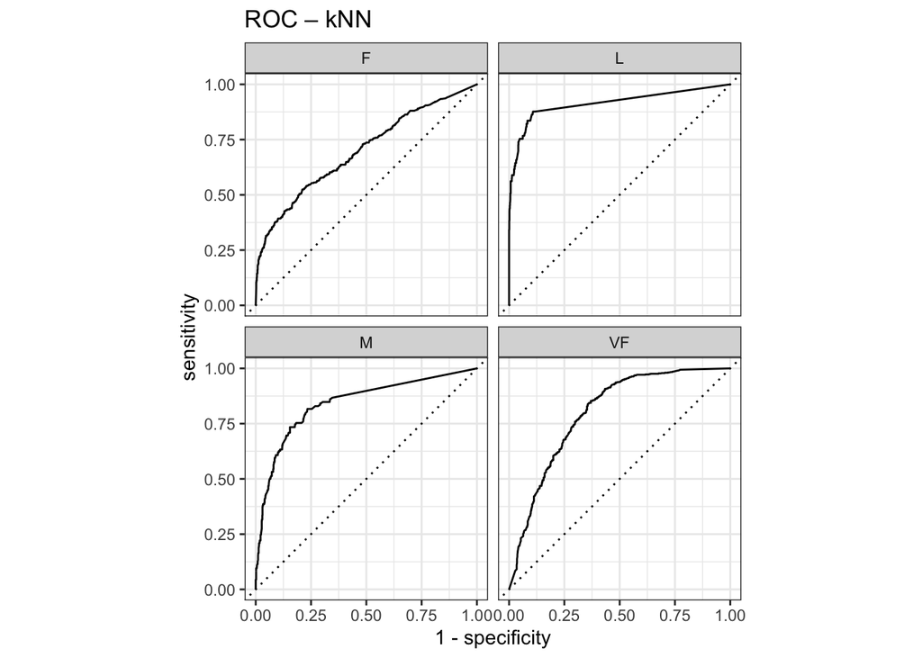

```r
# ROC – kNN
pred_knn %>%
  roc_curve(truth = class, .pred_VF:.pred_L) %>%
  autoplot() +
  labs(title = "ROC – kNN")
```

```r
# AUC
pred_all_hpc <- bind_rows(pred_multinom, pred_knn)

pred_all_hpc %>%
  group_by(model) %>%
  roc_auc(truth = class, .pred_VF:.pred_L)
```

```
# A tibble: 2 × 4
  model    .metric .estimator .estimate
  <chr>    <chr>   <chr>          <dbl>
1 knn      roc_auc hand_till      0.817
2 multinom roc_auc hand_till      0.744
```

### 4. Metryki z estymatorami macro i macro_weighted

```r
hpc_metrics <- metric_set(accuracy, bal_accuracy, precision, f_meas)

# macro
pred_all_hpc %>%
  group_by(model) %>%
  hpc_metrics(truth = class,
              estimate = .pred_class,
              estimator = "macro") %>%
  arrange(.metric, model)
```

```
# A tibble: 8 × 4
  model    .metric      .estimator .estimate
  <chr>    <chr>        <chr>          <dbl>
1 knn      accuracy     multiclass     0.649
2 multinom accuracy     multiclass     0.576
3 knn      bal_accuracy macro          0.711
4 multinom bal_accuracy macro          0.621
5 knn      f_meas       macro          0.591
6 multinom f_meas       macro          0.432
7 knn      precision    macro          0.623
8 multinom precision    macro          0.511
```

```r
# macro_weighted
pred_all_hpc %>%
  group_by(model) %>%
  hpc_metrics(truth = class,
              estimate = .pred_class,
              estimator = "macro_weighted") %>%
  arrange(.metric, model)
```

```
# A tibble: 8 × 4
  model    .metric      .estimator     .estimate
  <chr>    <chr>        <chr>              <dbl>
1 knn      accuracy     multiclass         0.649
2 multinom accuracy     multiclass         0.576
3 knn      bal_accuracy macro_weighted     0.700
4 multinom bal_accuracy macro_weighted     0.613
5 knn      f_meas       macro_weighted     0.637
6 multinom f_meas       macro_weighted     0.514
7 knn      precision    macro_weighted     0.638
8 multinom precision    macro_weighted     0.538
```

### 5. Wnioski

```r
# macierze klasyfikacji dla pogłębienia analizy klasy L
pred_multinom %>%
  conf_mat(truth = class, estimate = .pred_class)
```

```
          Truth
Prediction  VF   F   M   L
        VF 613 312  64  20
        F   39  76  48   5
        M    6   8  28  15
        L    2  14  18  33
```

```r
pred_knn %>%
  conf_mat(truth = class, estimate = .pred_class)
```

```
          Truth
Prediction  VF   F   M   L
        VF 545 192  44   9
        F   94 188  33   6
        M   18  24  70  17
        L    3   6  11  41
```

Porównując wyniki: `accuracy` i metryki `macro_weighted` mogą faworyzować model dobrze klasyfikujący dominującą klasę *VF*. Natomiast `bal_accuracy` i metryki `macro` lepiej eksponują słabość modeli wobec klasy *L*. Model, który osiąga wyższą `bal_accuracy`, lepiej radzi sobie z klasą mniejszościową, nawet jeśli jego ogólna `accuracy` jest nieco niższa.

## Zadanie 3

### 1. Trzy modele

```r
set.seed(2026)

peng3 <- penguins %>%
  drop_na() %>%
  select(species, bill_length_mm, bill_depth_mm, flipper_length_mm, body_mass_g)

split_peng3 <- initial_split(peng3, prop = 0.7, strata = species)
train_peng3 <- training(split_peng3)
test_peng3 <- testing(split_peng3)

# model 1: wieloklasowa regresja logistyczna
multinom_spec3 <- multinom_reg() %>%
  set_engine("nnet") %>%
  set_mode("classification")

multinom_fit3 <- multinom_spec3 %>%
  fit(species ~ ., data = train_peng3)

pred_mn3 <- test_peng3 %>%
  select(species) %>%
  bind_cols(predict(multinom_fit3, new_data = test_peng3)) %>%
  mutate(model = "multinom")

# model 2: kNN ze standaryzacją
knn_spec3 <- nearest_neighbor(neighbors = 7) %>%
  set_engine("kknn") %>%
  set_mode("classification")

knn_rec3 <- recipe(species ~ ., data = train_peng3) %>%
  step_normalize(all_numeric_predictors())

knn_wf3 <- workflow() %>%
  add_recipe(knn_rec3) %>%
  add_model(knn_spec3)

knn_fit3 <- knn_wf3 %>% fit(data = train_peng3)

pred_knn3 <- test_peng3 %>%
  select(species) %>%
  bind_cols(predict(knn_fit3, new_data = test_peng3)) %>%
  mutate(model = "knn")

# model 3: drzewo klasyfikacyjne
tree_spec3 <- decision_tree() %>%
  set_engine("rpart") %>%
  set_mode("classification")

tree_fit3 <- tree_spec3 %>%
  fit(species ~ ., data = train_peng3)

pred_tree3 <- test_peng3 %>%
  select(species) %>%
  bind_cols(predict(tree_fit3, new_data = test_peng3)) %>%
  mutate(model = "tree")
```

### 2. Macierze klasyfikacji i metryki per klasa

```r
cm_mn <- pred_mn3 %>% conf_mat(truth = species, estimate = .pred_class)
cm_knn <- pred_knn3 %>% conf_mat(truth = species, estimate = .pred_class)
cm_tree <- pred_tree3 %>% conf_mat(truth = species, estimate = .pred_class)

cm_mn
```

```
           Truth
Prediction  Adelie Chinstrap Gentoo
  Adelie        43         1      0
  Chinstrap      0        20      0
  Gentoo         1         0     36
```

```r
summary(cm_mn)
```

```
# A tibble: 13 × 3
   .metric              .estimator .estimate
   <chr>                <chr>          <dbl>
 1 accuracy             multiclass     0.980
 2 kap                  multiclass     0.969
 3 sens                 macro          0.977
 4 spec                 macro          0.989
 5 ppv                  macro          0.983
 6 npv                  macro          0.990
 7 mcc                  multiclass     0.969
 8 j_index              macro          0.966
 9 bal_accuracy         macro          0.983
10 detection_prevalence macro          0.333
11 precision            macro          0.983
12 recall               macro          0.977
13 f_meas               macro          0.980
```

```r
cm_knn
```

```
           Truth
Prediction  Adelie Chinstrap Gentoo
  Adelie        44         1      0
  Chinstrap      0        20      0
  Gentoo         0         0     36
```

```r
summary(cm_knn)
```

```
# A tibble: 13 × 3
   .metric              .estimator .estimate
   <chr>                <chr>          <dbl>
 1 accuracy             multiclass     0.990
 2 kap                  multiclass     0.984
 3 sens                 macro          0.984
 4 spec                 macro          0.994
 5 ppv                  macro          0.993
 6 npv                  macro          0.996
 7 mcc                  multiclass     0.985
 8 j_index              macro          0.978
 9 bal_accuracy         macro          0.989
10 detection_prevalence macro          0.333
11 precision            macro          0.993
12 recall               macro          0.984
13 f_meas               macro          0.988
```

```r
cm_tree
```

```
           Truth
Prediction  Adelie Chinstrap Gentoo
  Adelie        38         0      0
  Chinstrap      6        21      1
  Gentoo         0         0     35
```

```r
summary(cm_tree)
```

```
# A tibble: 13 × 3
   .metric              .estimator .estimate
   <chr>                <chr>          <dbl>
 1 accuracy             multiclass     0.931
 2 kap                  multiclass     0.894
 3 sens                 macro          0.945
 4 spec                 macro          0.971
 5 ppv                  macro          0.917
 6 npv                  macro          0.963
 7 mcc                  multiclass     0.900
 8 j_index              macro          0.916
 9 bal_accuracy         macro          0.958
10 detection_prevalence macro          0.333
11 precision            macro          0.917
12 recall               macro          0.945
13 f_meas               macro          0.923
```

### 3–4. Własny zestaw metryk i tabela zbiorcza

```r
my_metric_set <- metric_set(accuracy, bal_accuracy, f_meas, kap, mcc)

pred_all3 <- bind_rows(pred_mn3, pred_knn3, pred_tree3)

pred_all3 %>%
  group_by(model) %>%
  my_metric_set(truth = species,
                estimate = .pred_class,
                estimator = "macro_weighted") %>%
  arrange(.metric, desc(.estimate))
```

```
# A tibble: 15 × 4
   model    .metric      .estimator     .estimate
   <chr>    <chr>        <chr>              <dbl>
 1 knn      accuracy     multiclass         0.990
 2 multinom accuracy     multiclass         0.980
 3 tree     accuracy     multiclass         0.931
 4 knn      bal_accuracy macro_weighted     0.991
 5 multinom bal_accuracy macro_weighted     0.984
 6 tree     bal_accuracy macro_weighted     0.956
 7 knn      f_meas       macro_weighted     0.990
 8 multinom f_meas       macro_weighted     0.980
 9 tree     f_meas       macro_weighted     0.933
10 knn      kap          multiclass         0.984
11 multinom kap          multiclass         0.969
12 tree     kap          multiclass         0.894
13 knn      mcc          multiclass         0.985
14 multinom mcc          multiclass         0.969
15 tree     mcc          multiclass         0.900
```